# Having fun playing with Twitter data

Kelly Sovacool

2021-11-26

```r
library(here)
library(tidyverse)
library(rtweet)
```

```r
auth_setup_default()
```

```r
my_username <- 'kelly_sovacool'
me <- lookup_users(my_username)
num_tweets <- me[['statuses_count']]
#my_tweets_all <- get_timeline(user = me[['id']], n = num_tweets, retryonratelimit = TRUE) # Error: $ operator is invalid for atomic vectors
my_tweets <- get_timeline(user = me[['id']],
                          n = 1163, # 1164 failed, 1163 worked
                          retryonratelimit = TRUE)
my_tweets_orig <- my_tweets %>%
  filter(!startsWith(text, 'RT @')) # no retweets
my_tweets_orig_noreplies <- my_tweets_orig %>%
    filter(is.na(in_reply_to_status_id)) # no replies
```

Why does `get_timeline` fail for my account with `n > 1163`?

```r
oldest_tweet <- my_tweets[nrow(my_tweets), ]
print(oldest_tweet[['id_str']]) # this will change as I tweet more
# https://twitter.com/kelly_sovacool/status/1105862504889110534
older_tweets <- get_timeline(user = me[['id']],
                             n = 1,
                             max_id = "1105862504889110534")
```

this might be fixed by https://github.com/ropensci/rtweet/pull/627

```r
#devtools::install_github('ropensci/rtweet@coordinates')
my_tweets_all <- get_timeline(user = me[['id']], n = num_tweets, retryonratelimit = TRUE)
```

uh nope didn’t work. will continue using tweets newer than “1105862504889110534”

## most liked tweets

```r
print_embed <- function(status_id, tcount, screen_name = 'kelly_sovacool',
                        type = 'likes', n = 1) {
  emoji <- if_else(type == 'likes', '❤️','🔁')
  cat('#### ', n, ".  ", emoji, '**', tcount, '**\n',
      tweet_embed(screen_name = screen_name, status_id = status_id),
      sep = "")
}
```

```r
most_liked <- my_tweets_orig %>%
    slice_max(favorite_count, n = 5)
n <- 0
embeds <-
    apply(most_liked, MARGIN = 1,
           function(tweet) {
             n <<- n + 1
             print_embed(tweet[['id_str']], tweet[['favorite_count']],
                         type = 'likes', n = n)
               })
```

#### 1. ❤️**135**

> recently a prof was trying to be supportive telling me, "you'll publish in Cell/Nature/Science one day, you will 😊"  
> y'all shoulda seen his look of bewilderment when I replied "lol no I'll never submit a manuscript to a for-profit closed-access journal as long as I have any say"

> — Kelly Sovacool (@kelly_sovacool) [November 23, 2021](https://twitter.com/kelly_sovacool/status/1463241171946414084?ref_src=twsrc%5Etfw)

#### 2. ❤️**118**

> I passed my prelim exam!!! I'm about to be a PhD candidate!

> — Kelly Sovacool (@kelly_sovacool) [August 17, 2020](https://twitter.com/kelly_sovacool/status/1295427338616950784?ref_src=twsrc%5Etfw)

#### 3. ❤️**100**

> I found myself sending some of the same links over and over again to people who asked questions related to [#bioinformatics](https://twitter.com/hashtag/bioinformatics?src=hash&ref_src=twsrc%5Etfw), [#python](https://twitter.com/hashtag/python?src=hash&ref_src=twsrc%5Etfw), [#rstats](https://twitter.com/hashtag/rstats?src=hash&ref_src=twsrc%5Etfw), & [#git](https://twitter.com/hashtag/git?src=hash&ref_src=twsrc%5Etfw). So it was time to compile all the links in one convenient place!https://t.co/85m4Df6Ggz

> — Kelly Sovacool (@kelly_sovacool) [May 15, 2019](https://twitter.com/kelly_sovacool/status/1128700927916093440?ref_src=twsrc%5Etfw)

#### 4. ❤️**90**

> numpy seems to be doing a great job of ensuring that no women or other underrepresented folks will want to contribute

> — Kelly Sovacool (@kelly_sovacool) [September 24, 2020](https://twitter.com/kelly_sovacool/status/1309171854591045633?ref_src=twsrc%5Etfw)

#### 5. ❤️**72**

> YES! If that drunk-with-power feeling starts to fade, you can put your plots in R Markdown documents and RULE THE WORLD — I mean uhh, make reproducible reports!

> — Kelly Sovacool (@kelly_sovacool) [November 22, 2020](https://twitter.com/kelly_sovacool/status/1330508574737502210?ref_src=twsrc%5Etfw)

## most retweeted tweets

```r
most_rtd <- my_tweets_orig %>%
    slice_max(retweet_count, n = 5)
n <- 0
embeds <-
    apply(most_rtd, MARGIN = 1,
           function(tweet) {
             n <<- n + 1
             print_embed(tweet[['id_str']], tweet[['retweet_count']],
                         type = 'retweets', n = n)
               })
```

#### 1. 🔁**34**

> I found myself sending some of the same links over and over again to people who asked questions related to [#bioinformatics](https://twitter.com/hashtag/bioinformatics?src=hash&ref_src=twsrc%5Etfw), [#python](https://twitter.com/hashtag/python?src=hash&ref_src=twsrc%5Etfw), [#rstats](https://twitter.com/hashtag/rstats?src=hash&ref_src=twsrc%5Etfw), & [#git](https://twitter.com/hashtag/git?src=hash&ref_src=twsrc%5Etfw). So it was time to compile all the links in one convenient place!https://t.co/85m4Df6Ggz

> — Kelly Sovacool (@kelly_sovacool) [May 15, 2019](https://twitter.com/kelly_sovacool/status/1128700927916093440?ref_src=twsrc%5Etfw)

#### 2. 🔁**23**

> THIS 👇🏻 https://t.co/aPEh54zPFQ [pic.twitter.com/pItMjNBrCx](https://t.co/pItMjNBrCx)

> — Kelly Sovacool (@kelly_sovacool) [September 7, 2020](https://twitter.com/kelly_sovacool/status/1303021425398181889?ref_src=twsrc%5Etfw)

#### 3. 🔁**18**

> Hey UMich folks! The next [#SoftwareCarpentry](https://twitter.com/hashtag/SoftwareCarpentry?src=hash&ref_src=twsrc%5Etfw) workshop is coming up on Sept 5 & 6! It covers the unix shell, version control with [#git](https://twitter.com/hashtag/git?src=hash&ref_src=twsrc%5Etfw), and programming in [#rstats](https://twitter.com/hashtag/rstats?src=hash&ref_src=twsrc%5Etfw). Sign up ASAP if you're interested: https://t.co/13UioFKcDl

> — Kelly Sovacool (@kelly_sovacool) [August 24, 2019](https://twitter.com/kelly_sovacool/status/1165278560803794945?ref_src=twsrc%5Etfw)

#### 4. 🔁**14**

> [#BlackInMicro](https://twitter.com/hashtag/BlackInMicro?src=hash&ref_src=twsrc%5Etfw) week is coming up![@dr_kozik](https://twitter.com/dr_kozik?ref_src=twsrc%5Etfw) & [@KYT_ThatsME](https://twitter.com/KYT_ThatsME?ref_src=twsrc%5Etfw) are doing an awesome job organizing this: https://t.co/lQ0865WqmG

> — Kelly Sovacool (@kelly_sovacool) [September 10, 2020](https://twitter.com/kelly_sovacool/status/1304143884482535425?ref_src=twsrc%5Etfw)

#### 5. 🔁**12**

> Hey UMich people! I'm a co-host for CoderSpaces, a free virtual office hour where you can get help on coding/programming for your research projects! Our hosts are eager to help with expertise in R, Python, C++, Make, Snakemake, git/GitHub, HPC, & more: https://t.co/B7tbG5urlr [pic.twitter.com/u0T7NGJY8F](https://t.co/u0T7NGJY8F)

> — Kelly Sovacool (@kelly_sovacool) [September 9, 2021](https://twitter.com/kelly_sovacool/status/1435984568377561089?ref_src=twsrc%5Etfw)

## plots!

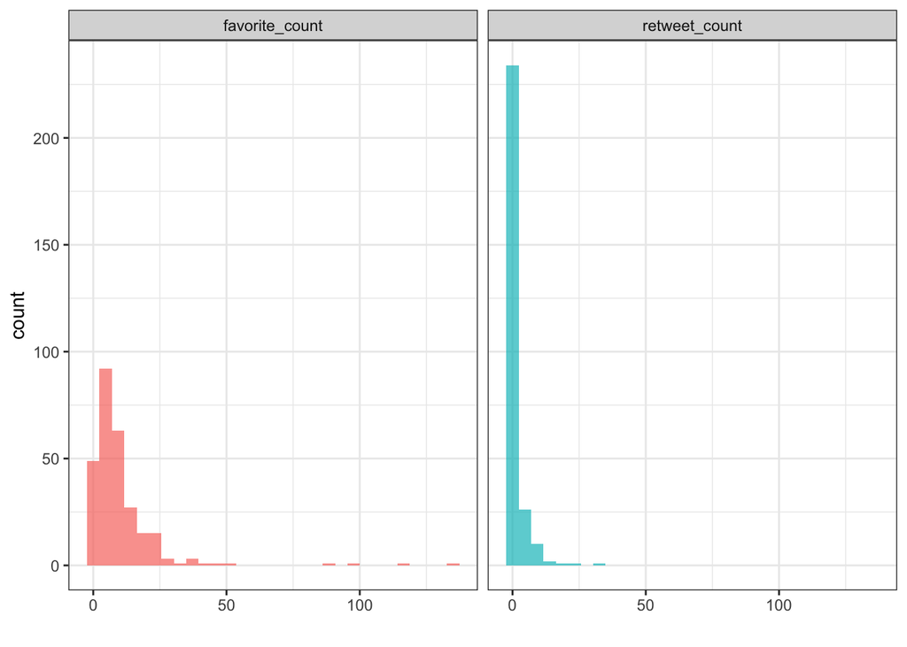

```r
my_tweets_orig_noreplies %>%
    pivot_longer(c(favorite_count, retweet_count),
                 names_to = 'engagement_type',
                 values_to = 'engagement_count') %>%
    ggplot(aes(engagement_count, fill = engagement_type)) +
    geom_histogram(alpha = 0.7) +
    facet_wrap('engagement_type', nrow = 1) +
    labs(x = '') +
    theme_bw() +
    theme(legend.position = 'none')
```

[output not shown]

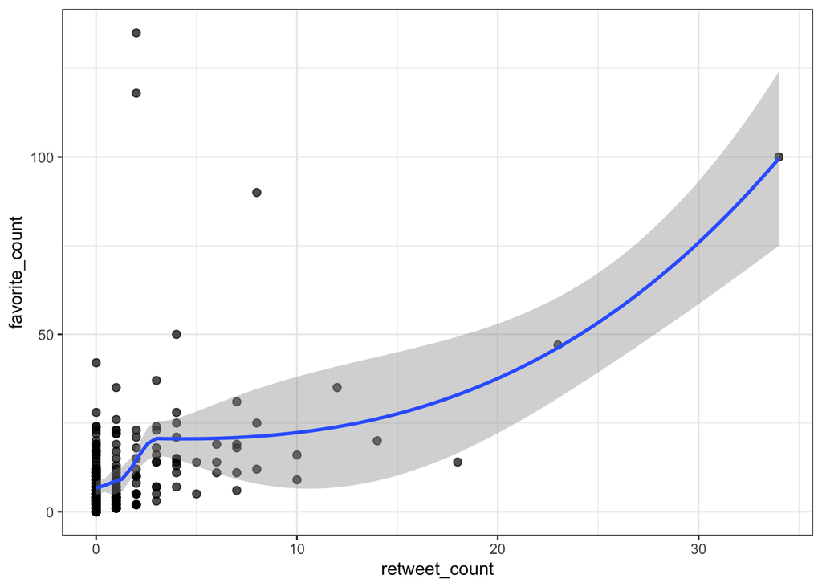

```r
my_tweets_orig_noreplies %>%
  ggplot(aes(retweet_count, favorite_count)) +
  geom_point(alpha = 0.7, size = 2) +
  geom_smooth(show.legend = FALSE) +
  theme_bw()
```

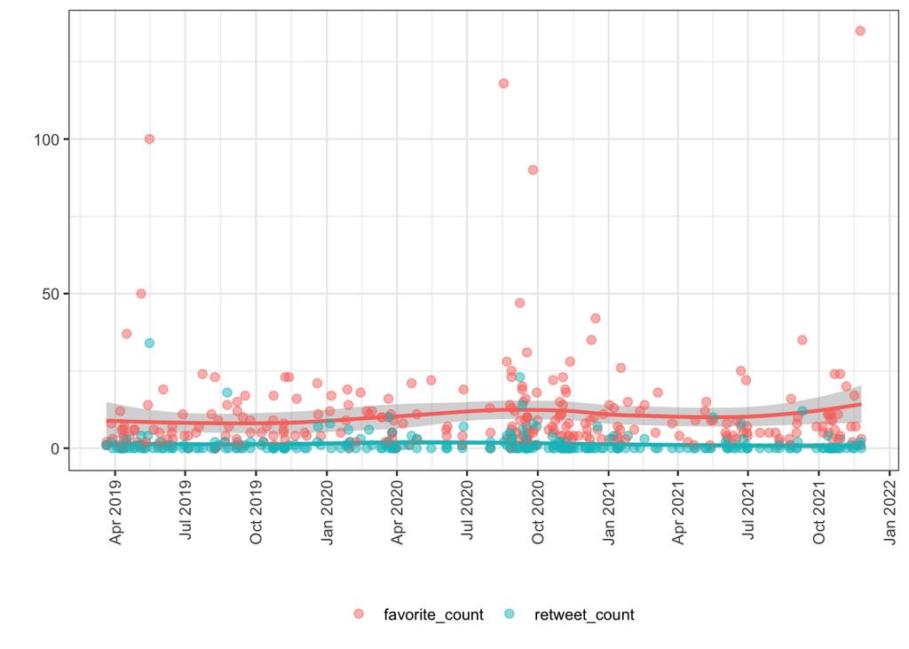

```r
my_tweets_orig_noreplies %>%
  mutate(created_datetime = lubridate::as_datetime(created_at, format = '%a %b %d %H:%M:%S +0000 %Y')) %>%
  pivot_longer(c(favorite_count, retweet_count),
               names_to = 'engagement_type',
               values_to = 'engagement_count') %>%
  ggplot(aes(created_datetime, engagement_count, color = engagement_type)) +
  geom_smooth(show.legend = FALSE) +
  geom_point(alpha = 0.5, size = 2) +
  scale_x_datetime(date_breaks = "3 months", date_labels = "%b %Y") +
  labs(y='', x='') +
  theme_bw() +
  theme(legend.title = element_blank(),
        legend.position = 'bottom',
        axis.text.x = element_text(angle = 90, vjust = 0.5, hjust=1))
```